# Week 6 Granger Causality and VAR models

```python
%matplotlib inline
import numpy as np
import pandas as pd
import statsmodels.api as sm
import matplotlib.pyplot as plt
from statsmodels.tsa.vector_ar.var_model import VAR
from statsmodels.tsa.statespace.varmax import VARMAX
from statsmodels.tsa.statespace.varmax import VARMAX
from math import sqrt
from sklearn.metrics import mean_absolute_error, mean_squared_error

import pandas as pd

# Loading dataset
data = pd.read_csv('C:/Users/arpan/Downloads/hw6_data_var.csv')
print(data.head())
print(data.columns)
```

```
  Unnamed: 0     PCE    AHE   PCEPI
0   3/1/2006  9122.1  20.04  88.473
1   4/1/2006  9174.8  20.17  88.850
2   5/1/2006  9215.1  20.13  89.070
3   6/1/2006  9240.8  20.22  89.285
4   7/1/2006  9322.6  20.30  89.601
Index(['Unnamed: 0', 'PCE', 'AHE', 'PCEPI'], dtype='object')
```

```python
import pandas as pd

# Loading the dataset and parsing the 'Unnamed: 0' column as dates
data = pd.read_csv('hw6_data_var.csv', parse_dates=['Unnamed: 0'], index_col='Unnamed: 0')
data.index.name = 'Date'
print(data.head())
```

```
             PCE    AHE   PCEPI
Date
3/1/2006  9122.1  20.04  88.473
4/1/2006  9174.8  20.17  88.850
5/1/2006  9215.1  20.13  89.070
6/1/2006  9240.8  20.22  89.285
7/1/2006  9322.6  20.30  89.601
```

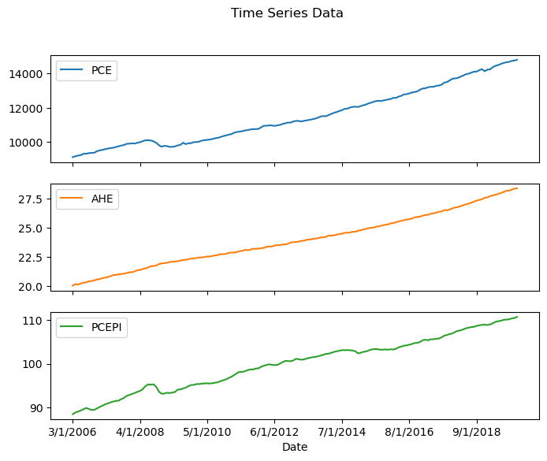

```python
import matplotlib.pyplot as plt
data.plot(subplots=True, figsize=(8, 6))
plt.suptitle('Time Series Data')
plt.show()
```

```python
# Checking for missing values
print(data.isnull().sum())
```

```
PCE      0
AHE      0
PCEPI    0
dtype: int64
```

```python
from statsmodels.tsa.stattools import adfuller
def adf_test(series, title=''):
    result = adfuller(series, autolag='AIC')
    print(f'ADF Statistic for {title}: {result[0]}')
    print(f'p-value: {result[1]}')
    for key, value in result[4].items():
        print('Critical Values:')
        print(f'   {key}, {value}')

# Performing ADF test on each time series
adf_test(data['PCE'], 'PCE')
adf_test(data['AHE'], 'AHE')
adf_test(data['PCEPI'], 'PCEPI')
```

```
ADF Statistic for PCE: 2.189889423685395
p-value: 0.9988740824722805
Critical Values:
   1%, -3.471118535474365
Critical Values:
   5%, -2.8794405060097024
Critical Values:
   10%, -2.576313761526591
ADF Statistic for AHE: 1.6800317871987092
p-value: 0.9980788747908695
Critical Values:
   1%, -3.4729792729247793
Critical Values:
   5%, -2.8802520918255534
Critical Values:
   10%, -2.5767469641683105
ADF Statistic for PCEPI: -0.43415162454914763
p-value: 0.9042386307188914
Critical Values:
   1%, -3.47086589632514
Critical Values:
   5%, -2.879330279087651
Critical Values:
   10%, -2.57625492712671
```

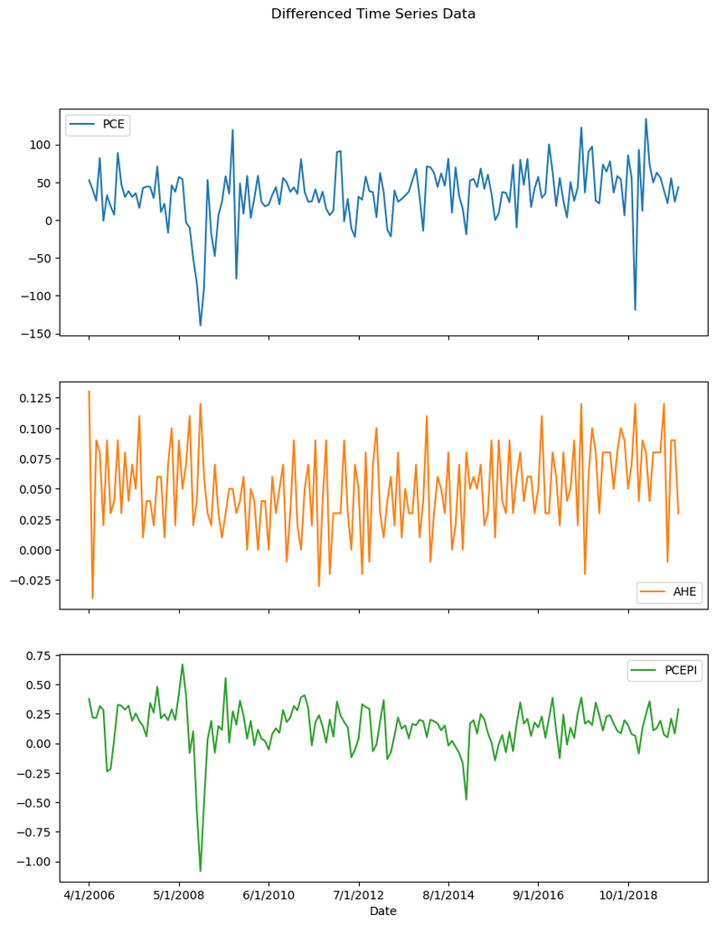

```
ADF Statistic for Differenced PCE: -6.605708754796354
p-value: 6.564987669533085e-09
Critical Values:
   1%, -3.471118535474365
Critical Values:
   5%, -2.8794405060097024
Critical Values:
   10%, -2.576313761526591
ADF Statistic for Differenced AHE: -1.0122757516928884
p-value: 0.7487607125683687
Critical Values:
   1%, -3.474714913481481
Critical Values:
   5%, -2.881008708148148
Critical Values:
   10%, -2.5771508444444446
ADF Statistic for Differenced PCEPI: -7.507424986143682
p-value: 4.0994509674372776e-11
Critical Values:
   1%, -3.47086589632514
Critical Values:
   5%, -2.879330279087651
Critical Values:
   10%, -2.57625492712671
```

```python
# Differencing the data to make it stationary
data_diff = data.diff().dropna()
# Plot the differenced data
data_diff.plot(subplots=True, figsize=(10, 12))
plt.suptitle('Differenced Time Series Data')
plt.show()

# Checking stationarity again after differencing
adf_test(data_diff['PCE'], 'Differenced PCE')
adf_test(data_diff['AHE'], 'Differenced AHE')
adf_test(data_diff['PCEPI'], 'Differenced PCEPI')
```

```python
# Second differencing for AHE
data_diff['AHE_diff2'] = data['AHE'].diff().diff().dropna()

# Dropping NA values resulting from differencing
data_diff = data_diff.dropna()

# Performing ADF test on second differenced AHE
adf_test(data_diff['AHE_diff2'].dropna(), 'Second Differenced AHE')
```

```
ADF Statistic for Second Differenced AHE: -5.351745213733153
p-value: 4.274243730469566e-06
Critical Values:
   1%, -3.474714913481481
Critical Values:
   5%, -2.881008708148148
Critical Values:
   10%, -2.5771508444444446
```

```python
# Checking the stationarity of second differenced AHE
adf_test(data_diff['AHE_diff2'].dropna(), 'Second Differenced AHE')
```

```
ADF Statistic for Second Differenced AHE: -5.351745213733153
p-value: 4.274243730469566e-06
Critical Values:
   1%, -3.474714913481481
Critical Values:
   5%, -2.881008708148148
Critical Values:
   10%, -2.5771508444444446
```

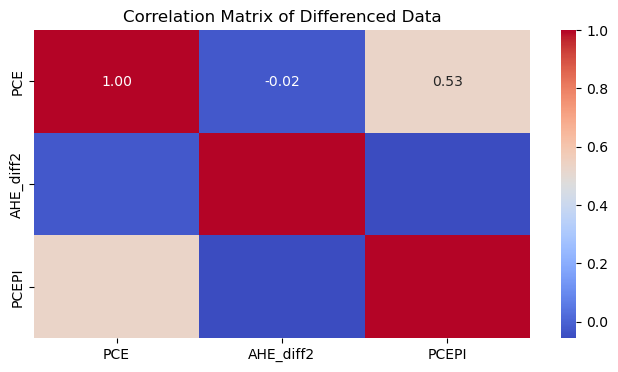

```python
import seaborn as sns
import matplotlib.pyplot as plt

# Selecting relevant columns for the correlation matrix
data_corr = data_diff[['PCE', 'AHE_diff2', 'PCEPI']]

# Calculating the correlation matrix
correlation_matrix = data_corr.corr()

# Plotting the correlation matrix
plt.figure(figsize=(8, 4))
sns.heatmap(correlation_matrix, annot=True, cmap='coolwarm', fmt='.2f')
plt.title('Correlation Matrix of Differenced Data')
plt.show()
```

Part 2 – 40 pts Granger Causality

A. Personal Consumption Expenditures (PCE) represent the total amount of money spent by consumers on goods and services. Average Hourly Earnings (AHE) indicate the average income earned per hour by workers. Intuitively, if consumers have higher earnings (AHE), they are likely to spend more, leading to an increase in PCE. Therefore, it can be argued that changes in AHE might lead to changes in PCE. However, it's also possible that higher consumption (PCE) could drive demand for labor, potentially increasing AHE.

B. 8 pts Difference the two variables

```python
# Performing differencing to achieve stationarity (already done in EDA)
data_diff = data.diff().dropna()

# Second differencing for AHE to achieve stationarity
data_diff['AHE_diff2'] = data['AHE'].diff().diff().dropna()
data_diff = data_diff.dropna()
print(data_diff.head())
```

```
           PCE   AHE  PCEPI  AHE_diff2
Date
5/1/2006  40.3 -0.04  0.220      -0.17
6/1/2006  25.7  0.09  0.215       0.13
7/1/2006  81.8  0.08  0.316      -0.01
8/1/2006  -0.8  0.02  0.284      -0.06
9/1/2006  32.9  0.09 -0.239       0.07
```

C. 8 pts Check Granger Causality for the direction you stated in 2A, return plot of results.

D.8 pts Check Granger Causality for the opposite direction you stated in 2A, return plot of results

```
Granger Causality Test for AHE_diff2 causing PCE

Granger Causality
number of lags (no zero) 1
ssr based F test:         F=0.0150  , p=0.9028  , df_denom=160, df_num=1
ssr based chi2 test:   chi2=0.0152  , p=0.9018  , df=1
likelihood ratio test: chi2=0.0152  , p=0.9018  , df=1
parameter F test:         F=0.0150  , p=0.9028  , df_denom=160, df_num=1

Granger Causality
number of lags (no zero) 2
ssr based F test:         F=0.0339  , p=0.9667  , df_denom=157, df_num=2
ssr based chi2 test:   chi2=0.0699  , p=0.9656  , df=2
likelihood ratio test: chi2=0.0699  , p=0.9656  , df=2
parameter F test:         F=0.0339  , p=0.9667  , df_denom=157, df_num=2

Granger Causality
number of lags (no zero) 3
ssr based F test:         F=0.7324  , p=0.5342  , df_denom=154, df_num=3
ssr based chi2 test:   chi2=2.2970  , p=0.5131  , df=3
likelihood ratio test: chi2=2.2808  , p=0.5162  , df=3
parameter F test:         F=0.7324  , p=0.5342  , df_denom=154, df_num=3

Granger Causality
number of lags (no zero) 4
ssr based F test:         F=0.6602  , p=0.6206  , df_denom=151, df_num=4
ssr based chi2 test:   chi2=2.7981  , p=0.5922  , df=4
likelihood ratio test: chi2=2.7740  , p=0.5963  , df=4
parameter F test:         F=0.6602  , p=0.6206  , df_denom=151, df_num=4
```

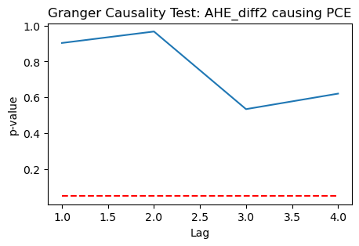

```
Granger Causality Test for PCE causing AHE_diff2

Granger Causality
number of lags (no zero) 1
ssr based F test:         F=0.0096  , p=0.9221  , df_denom=160, df_num=1
ssr based chi2 test:   chi2=0.0098  , p=0.9212  , df=1
likelihood ratio test: chi2=0.0098  , p=0.9212  , df=1
parameter F test:         F=0.0096  , p=0.9221  , df_denom=160, df_num=1

Granger Causality
number of lags (no zero) 2
ssr based F test:         F=1.2799  , p=0.2810  , df_denom=157, df_num=2
ssr based chi2 test:   chi2=2.6413  , p=0.2670  , df=2
likelihood ratio test: chi2=2.6200  , p=0.2698  , df=2
parameter F test:         F=1.2799  , p=0.2810  , df_denom=157, df_num=2

Granger Causality
number of lags (no zero) 3
ssr based F test:         F=1.6328  , p=0.1841  , df_denom=154, df_num=3
ssr based chi2 test:   chi2=5.1209  , p=0.1632  , df=3
likelihood ratio test: chi2=5.0412  , p=0.1688  , df=3
parameter F test:         F=1.6328  , p=0.1841  , df_denom=154, df_num=3

Granger Causality
number of lags (no zero) 4
ssr based F test:         F=1.3854  , p=0.2417  , df_denom=151, df_num=4
ssr based chi2 test:   chi2=5.8719  , p=0.2089  , df=4
likelihood ratio test: chi2=5.7667  , p=0.2173  , df=4
parameter F test:         F=1.3854  , p=0.2417  , df_denom=151, df_num=4
```

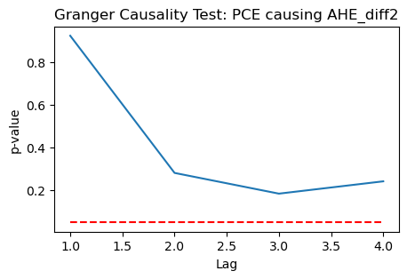

```python
from statsmodels.tsa.stattools import grangercausalitytests, q_stat
def granger_causality_test(data, variables, maxlag=5, alpha=0.05, title=''):
    granger_results = grangercausalitytests(data, maxlag=maxlag, verbose=True)
    res_list = []
    for lag, v in granger_results.items():
        res = {}
        res['Lag'] = lag
        for test, stats in v[0].items():
            res[test] = stats[1]  # p-value
        res_list.append(res)

    pvals = pd.DataFrame(res_list)
    pvals.set_index('Lag', inplace=True)
    pvals_graph = pvals['params_ftest']

    # Plot the p-values
    plt.figure(figsize=(5, 3))
    pvals_graph.plot(title=title)
    alpha_ser = pd.Series([alpha]*len(pvals_graph), index=pvals_graph.index)
    alpha_ser.plot(color='red', linestyle='--')
    plt.ylabel('p-value')
    plt.xlabel('Lag')
    plt.show()


print("Granger Causality Test for AHE_diff2 causing PCE")
granger_causality_test(data_diff[['PCE', 'AHE_diff2']].dropna(), variables=['PCE', 'AHE_diff2'], maxlag=4, title='Granger Causality Test: AHE_diff2 causing PCE')


print("Granger Causality Test for PCE causing AHE_diff2")
granger_causality_test(data_diff[['AHE_diff2', 'PCE']].dropna(), variables=['AHE_diff2', 'PCE'], maxlag=4, title='Granger Causality Test: PCE causing AHE_diff2')
```

E. 8 pts Summarize your findings. You must understand the underlying null hypothesis of test.

The null hypothesis for the Granger causality test states that the lagged values of one time series do not provide any statistically significant information about another time series.

For all lags tested (1 to 4), the p-values are significantly greater than 0.05.Therefore, we fail to reject the null hypothesis, suggesting that lagged values of AHE_diff2 do not Granger-cause PCE at any of the lags tested. For all lags tested (1 to 4), the p-values are also greater than 0.05.

Similarly, we fail to reject the null hypothesis, suggesting that lagged values of PCE do not Granger-cause AHE_diff2 at any of the lags tested.

The Granger causality tests for both directions do not provide evidence to reject the null hypothesis for any of the lags tested. This indicates that there is no significant Granger causality between AHE_diff2 and PCE in either direction within the lag range considered (1 to 4). Past values of AHE do not contain predictive information about PCE, and past values of PCE do not contain predictive information about AHE (after second differencing).

Part 3 – 40 pts VARMA modeling